# Labour force analysis by industry

# Health Care and Social Assistance

*Last updated on 2020-09-19.*

A total of 1,791,824 individuals were employed in Health Care and Social Assistance in Feb 2020, before the onset of COVID-19 spread in Australia.

A total of 1,731,894 individuals were employed in the most recent quarter of May 2020, which is a decrease of 3.34 percentage points since Feb 2020.

## Change in employment growth/decline

We can visualise the change in employment for Health Care and Social Assistance compared to all other industries as the rate of employment growth or decline since Nov 1984.

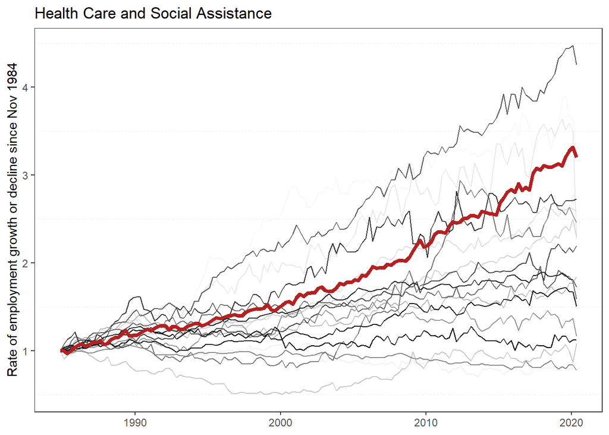

## Number of employed persons over time

We can visualise the total number of employed persons for Health Care and Social Assistance since Nov 1984.

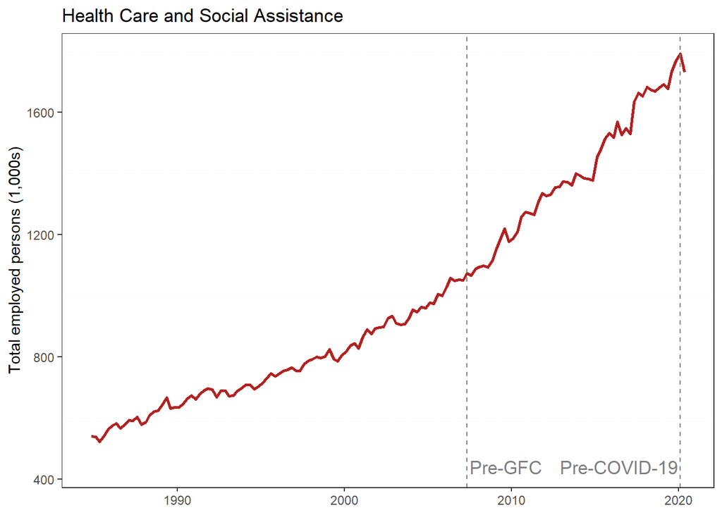

## Changes in total persons employed over time

If we subtract the employed persons count by the preceding quarter’s count, we can visualise the total increase or decrease in employment numbers. This allows us to directly compare how much employment numbers have fluctuated over time between different industries.

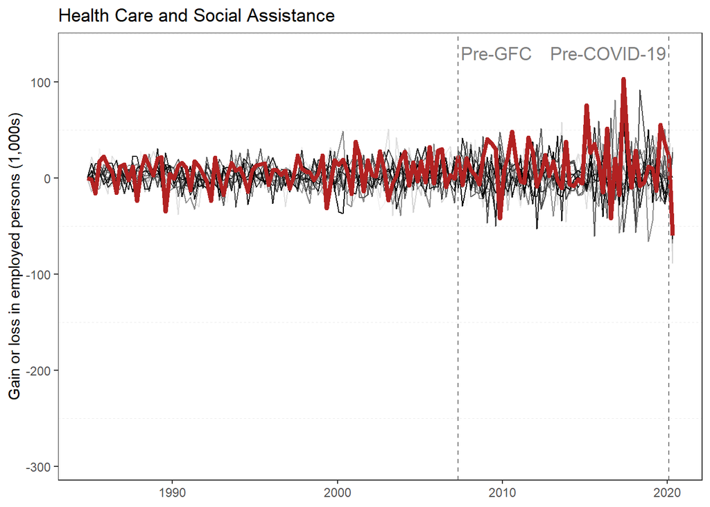

**Note**: The trend for Health Care and Social Assistance is highlighted in red.